# 260677676 MATH525 Assignment 1 ver4

##2.24 For some $c_0, c_1, k \in \mathbb{R}$
$$L(n) = k* Var(\bar{y}_s) = k(1- \frac{n}{N})\frac{S^2}{n}$$
$$C(n) = c_0 + c_1 n$$
find
$$n = argmin_{n \in \mathbb{N}} L(n)+C(n)$$
We differentiate $L(n) + C(n)$ with respect to n and set it to zero
$$\frac{\partial L(n) + C(n)}{\partial n} = \frac{\partial}{\partial n} \{kS^2(\frac{1}{n}-\frac{1}{N})+c_0 + c_1n\}$$
$$= \frac{-kS^2}{n^2} + c_1 = 0$$
$$\implies c_1 = \frac{kS^2}{n^2} \implies n^2 = \frac{kS^2}{c_1}$$
$$\implies n = S\sqrt{\frac{k}{c_1}}$$
So choose $\lceil n \rceil$

##2.26 Show that for systematic sampling $\forall i = 1, ..., N$

$\pi_i = P(i \in S) = \frac{n}{N}$ , but not necessarily SRS, i.e.

$$P(S) \neq \frac{1}{{N \choose n}}$$
Let $K = \frac{N}{n}$ be assumed to be a positive integer (thus assumed $n | N$. and let $R = \{1, 2, ..., K\}$ then we know the set of population $U$ can be partitioned into
$$\{1+K, 1+2K, ...1+(n-1)K \} = [1]_K$$
$$\{2, 2+K, ... , 2 +(n-1)K\} = [2]_K$$
. . .
$$\{K, 2K, ... ,nK\} = [0]_K = [K]_K$$
So each element $i \in U$ $\pi_i = \frac{1}{K} = \frac{n}{N}$, but we only have K possible samples. Therefore for all possible sample of size n in this design
$$P(S) = \frac{1}{K} = \frac{n}{N}$$

##2.28

SRS with replacement:

Let $y_i \in U$. $y_i$ can appear $k$ many times in the sample of size n where $k \in \{0, ..., n\}$ \ Define
$$Q_i = \{\text{Number of times } y_i \text{ appear in a sample }\}$$

Define our estimator of the population total
$$\widehat{t} = \frac{N}{n} \sum_{i=1}^N Q_i y_i$$
$$t= \sum_{i=1}^N y_i$$
##(a)

$P(Q_1= q_1, Q_2 =q_2, ... , Q_N = q_n) = p(Q, n) *\frac{1}{N}^n$ for some $p(Q,n)$. Since it shows the number of partitioning $n$ into $q1, q2, ..., q_N$, $p(Q, n)$ will be the multinomial coefficient. i.e.
$$p(Q,n) = {n \choose q_1, q_2, ... , q_N}$$
$$P(Q_1= q_1, Q_2 =q_2, ... , Q_N = q_n) = {n \choose q_1, q_2, ... , q_N} *\frac{1}{N}^n =$$
$${n \choose q_1, q_2, ... , q_N} \frac{1}{N}^{q_1}\frac{1}{N}^{q_2} ...\frac{1}{N}^{q_N}$$
which is a case of multinomial pmf.
$$P(Q_1= q_1, Q_2 =q_2, ... , Q_N = q_N) = {n \choose q_1, q_2, ... , q_N} \prod_{i=1}^N p_i^{q_i}$$

##(b)

For a multinomial random vector
$$Y = (Y_1, ..., Y_N) \sim multinomial(n, \vec{p} = (p_1, ... , p_N))$$
, we have its expected value
$$E[Y] = n\vec{p}= (np_1, np_2, ..., np_N)$$
For our case, we will have
$$E[Q] = n\vec{p}_Q = (\frac{n}{N}, \frac{n}{N}, ..., \frac{n}{N})$$
There $\forall i$ we have
$$E[Q_i] = \frac{n}{N}$$
$$Var[Q_i] = n(\frac{1}{N})(1-\frac{1}{N})$$
$$Cov(Q_i, Q_j) = -\frac{n}{N^2} \ i \neq j$$

Now, for $E[\widehat{t}]= E[\frac{N}{n} \sum_{i=1}^N Q_i y_i]$
$$E[\frac{N}{n} \sum_{i=1}^N Q_i y_i] = \frac{N}{n}\sum_{i=1}^Ny_iE[Q_i] = \frac{N}{n} \sum_{i=1}^N y_i\frac{n}{N} = \frac{N}{n} \frac{n}{N} \sum_{i=1}^N y_i = \sum_{i=1}^N y_i$$
Proving that it is an unbiased estimator of t.

##(c)

$$Var(\widehat{t}) = Var(\frac{N}{n} \sum_{i=1}^N Q_i y_i) = \frac{N^2}{n^2}Var(\sum_{i=1}^N Q_i y_i) =$$

$$= \frac{N^2}{n^2}\sum_{i=1}^{N}\sum_{j=1}^{N} y_i y_j Cov(Q_i, Q_j) =$$
$$\frac{N^2}{n^2}[\sum_{i=1}^{N}y_i^2Var(Q_i)+\sum_{i=1}^{N}\sum_{j\neq i}^{N}Cov(Q_i, Q_j)] =$$
$$\frac{N^2}{n^2}[\frac{n}{N}\frac{N-1}{N}\sum_{i=1}^{N}y_i^2-\frac{n}{N^2} \sum_{i=1}^{N}\sum_{j \neq i}^{N}y_iy_j] =$$
$$\frac{N^2}{n^2}[\frac{n}{N}\sum_{i=1}^{N}y_i^2 -\frac{n}{N^2}\sum_{i=1}^{N}\sum_{j=1}^{N}y_iy_j] =$$
$$\frac{N}{n}\sum_{i=1}^{N}y_i^2 - \frac{1}{n}\sum_{i=1}^{N}\sum_{j=1}^{N} y_iy_j = \frac{N}{n}[N\sum_{i=1}^{N}y_i^2 -\frac{1}{N}(\sum_{i=1}^{N}y_i)^2] =$$
$$\frac{N}{n}(N-1)S^2$$
##2.29 We can interpret this with recursive definition of
$$S_0 = \{1, 2, .. n \}, u_k \sim U(0,1)$$
given $S_{k-1}$
$$S_k|S_{k-1} =$$

We show this by induction on N.

###Base Case

$N = 0$: You can only pick the empty sample (sample size of zero), so it trivially holds. \ $N = 1$

Likewise, you can only pick one sample. Let $U = \{1\}$ be a population of 1. Then the only possible sample of size n (nonzero) is to have sample $S = U$. then
$$P(S) = P(U) = 1 = \frac{1}{ {1 \choose 1}}$$
Thus it is an SRS.

###Inductive step.

Suppose $S_{N-1-n}$ is an SRS of size n for some $N \in \mathbb{N}$ and all possible n. Then for $S_{N-n}$, given $S_{N-1-n}$
$$S_{N-n}|S_{N-1-n} =$$
$$\begin{cases}
S_{N-1-n} & P(S_{N-n}= S_{N-1-n}|S_{N-1-n}) = P(u_{N-n} > \frac{n}{n+(N-n)}) = \frac{N-n}{N}
\\
S_{N-1-n} \backslash\{j\} \cup \{N-n\}& P(S_{N-n} \neq S_{N-1-n}|S_{N-1-n}, j) = P(u_{N-n} \leq \frac{n}{n+(N-n)}) = \frac{n}{N}
\end{cases}$$
Due to our inductive hypothesis $P(S_{N-1-n}) = \frac{1}{{N-1 \choose n }} = \frac{n! (N-1-n)!}{(N-1)!}$ so eventually we have

$$P(S_{N-n}^*=S_{N-1-n}^*) = P(S_{N-n}= S_{N-1-n}|S_{N-1-n})P(S_{N-1-n}) = \frac{n! (N-1-n)!}{(N-1)!} * \frac{N-n}{N} =$$
$$\frac{n! (N-n)!}{N!} = \frac{1}{{N \choose n}}$$
For the other case, let $S_{N-1-n}^*$ be any one particular set constructed by following scheme.
$$P(N \in S_{N-n}^*) = \frac{n}{N} = \frac{{N-1\choose n-1}}{{N \choose n}}$$

but if $s \neq N$ s is from the $S_{N-1-n}$, which is a random sample. You can understand it as taking a sample size of n from $S_{N-1-n}$, and choose which one to replace with N (or equivalently choosing which n-1 elements to preserve). Especially since any element in $S_{N-1-n}$ has an equal chance of being chosen, and due to our inductive hypothesis, marginally the element chosen to be replaced can be any one of N-n values not chosen once having been replaced.
$$P(j \notin S^*_{N-n}, j \in S^*_{N-1-n}, S^*_{N-1-n}) =$$
$$P(j \notin S^*_{N-n}, j \in S^*_{N-1-n},|S^*_{N-1-n} )P(S^*_{N-1-n})$$
$$= \frac{1}{n}\frac{1}{{N-1\choose n}} = \frac{1}{n}\frac{(n-1)! (N-1-n)!}{(N-1)!} = \frac{1}{N-n}\frac{1}{{N-1 \choose n-1 }}$$
Now, there can be $N-n$ for $i$, the values replaced, so we wil; get the
$$P(j \notin S^*_{N-n}, j \in S^*_{N-1-n}) = \frac{1}{N-n}$$

$$P(S^*_{N-n}| j \notin S^*_{N-n}, j \in S^*_{N-1-n}) = \frac{P(S^*_{N-n}, j \notin S^*_{N-n}, j \in S^*_{N-1-n})}{P(j \notin S^*_{N-n}, j \in S^*_{N-1-n})}$$

$$\frac{1}{N-n}\frac{1}{{N-1 \choose n-1 }} * (N-n) = \frac{1}{{N-1 \choose n-1}}$$
but by our construction,
$$P(S^*_{N-n}| j \notin S^*_{N-n}, j \in S^*_{N-1-n}) = P(i \in (S_{N-n} \cap S_{N-1-n}) \ |N \in S_{N-n}) = \frac{1}{{N-1 \choose n-1}}$$

Proving our claim. ## 2.37

```r
ipums <- read_csv('ipums.csv')
head(ipums)
```

```
## # A tibble: 6 x 16
##   Stratum   Psu Inctot   Age   Sex  Race Hispanic Marstat Ownershg Yrsusa
##     <dbl> <dbl>  <dbl> <dbl> <dbl> <dbl>    <dbl>   <dbl>    <dbl>  <dbl>
## 1       1     1   4105    18     1     2        0       5        0      0
## 2       1     1   7795    20     1     1        0       5        2      0
## 3       1     1  16985    24     1     1        0       1        1      0
## 4       1     1   7045    21     1     1        0       1        2      0
## 5       1     1   2955    23     1     1        0       5        2      0
## 6       1     1      0    17     1     1        0       5        1      0
## # … with 6 more variables: School <dbl>, Educrec <dbl>, Labforce <dbl>,
## #   Occ <dbl>, Classwk <dbl>, VetStat <dbl>
```

```r
dim(ipums)
```

```
## [1] 53461    16
```

### (a)

The process of topcoding would shadow the true distribution of total personal income if one takes a model-based approach. It would also make it harder to perform a more accurate inference.

### (b)

```r
ipums_complete = ipums %>% filter(!is.na(Inctot))
#Verify that none of the data is missing
dim(ipums_complete)
```

```
## [1] 53461    16
```

```r
set.seed(329)

srs_pilot = ipums_complete %>% slice(sample(1:nrow(ipums_complete),
                                               size=50, replace=F))
dim(srs_pilot)
```

```
## [1] 50 16
```

```r
head(srs_pilot)
```

```
## # A tibble: 6 x 16
##   Stratum   Psu Inctot   Age   Sex  Race Hispanic Marstat Ownershg Yrsusa
##     <dbl> <dbl>  <dbl> <dbl> <dbl> <dbl>    <dbl>   <dbl>    <dbl>  <dbl>
## 1       7    61   8510    43     1     1        0       1        1      0
## 2       6    54      0    57     2     1        0       1        1      0
## 3       6    55   -805    33     2     1        0       3        2      0
## 4       6    52      0    46     2     1        0       3        1      0
## 5       9    81  10535    65     1     1        0       1        1      0
## 6       2    20   8300    30     1     1        1       1        2      0
## # … with 6 more variables: School <dbl>, Educrec <dbl>, Labforce <dbl>,
## #   Occ <dbl>, Classwk <dbl>, VetStat <dbl>
```

```r
srs_pilot %>%
  summarise(SampleMean=mean(Inctot),
                          SampleVar = var(Inctot),
                          SampleSD = sd(Inctot))  %>%
  gather(stat,val) %>%
  kable(.,format="html",digits=0) %>%
  kable_styling(.)
```

| stat | val |
| --- | --- |
| SampleMean | 8321 |
| SampleVar | 85300547 |
| SampleSD | 9236 |

From lectures we have learned that
$$n = \frac{S^2 Z_{0.025}^2}{e^2 + \frac{S^2 Z_{0.025}^2}{N}} =$$
$$\frac{n_0}{1+\frac{n_0}{N}}$$
where $N = 53461$, $e = 700$ and $n_0 = \frac{S^2 Z_{0.025}^2}{e^2}$

Let me use the formula using the sample variance $\widehat{S^2}$

```r
#Number of population unit
N = 53461
#Margin of error
e = 700

pilot_summary = srs_pilot %>%
  summarise(SampleMean=mean(Inctot),SampleVar = var(Inctot), SampleSD = sd(Inctot))

#Extracting the sample variance
S.2 = pilot_summary$SampleVar
#Normal quantile (1.96)
Z.a = qnorm(0.975)
#First candidate for the sample size
n_a =  (S.2*Z.a^2)/(e^2 + (S.2 * Z.a^2)/N)

#Now find the second candidate for the sample size using another formula and check whether the two candidates match\

n_0 = (S.2 * Z.a^2)/(e^2)

n_b = (n_0)/(1+ n_0/N)

n_a
```

```
## [1] 660.47
```

```r
n_b
```

```
## [1] 660.47
```

Our ideal sample size is $ceiling(660.47) = 661$ population units.

###(c)

```r
set.seed(329)
srs_661 = ipums_complete %>% slice(sample(1:nrow(ipums_complete),
                                               size=661, replace=F))
dim(srs_661)
```

```
## [1] 661  16
```

```r
head(srs_661)
```

```
## # A tibble: 6 x 16
##   Stratum   Psu Inctot   Age   Sex  Race Hispanic Marstat Ownershg Yrsusa
##     <dbl> <dbl>  <dbl> <dbl> <dbl> <dbl>    <dbl>   <dbl>    <dbl>  <dbl>
## 1       7    61   8510    43     1     1        0       1        1      0
## 2       6    54      0    57     2     1        0       1        1      0
## 3       6    55   -805    33     2     1        0       3        2      0
## 4       6    52      0    46     2     1        0       3        1      0
## 5       9    81  10535    65     1     1        0       1        1      0
## 6       2    20   8300    30     1     1        1       1        2      0
## # … with 6 more variables: School <dbl>, Educrec <dbl>, Labforce <dbl>,
## #   Occ <dbl>, Classwk <dbl>, VetStat <dbl>
```

```r
#Estimated total income for the population
srs_661 %>%
  summarise(SampleMean=mean(Inctot),
                          SampleVar = var(Inctot),
                          SampleSD = sd(Inctot),
                          t_hat = mean(Inctot)*N,
                          se_t_hat = N*sqrt((1 - 661/N))*sd(Inctot)/sqrt(661))  %>%
  gather(stat,val) %>%
  kable(.,format="html",digits=0) %>%
  kable_styling(.)
```

| stat | val |
| --- | --- |
| SampleMean | 9309 |
| SampleVar | 115375475 |
| SampleSD | 10741 |
| t_hat | 497663677 |
| se_t_hat | 22196859 |

```r
srs_design = survey::svydesign(id=~1,data=srs_661, fpc=rep(N,661))

svytotal(~Inctot,srs_design)
```

```
##            total       SE
## Inctot 497663677 22196859
```

```r
confint(svytotal(~Inctot, srs_design))
```

```
##            2.5 %    97.5 %
## Inctot 454158633 541168721
```

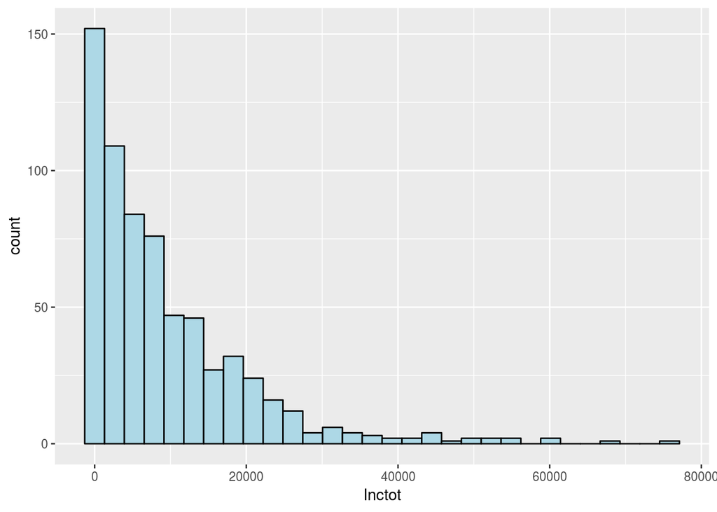

```r
ggplot(srs_661,aes(x=Inctot)) + geom_histogram(fill="lightblue",col="black")
```